# In the first st_buffer example above, how many quad segments should be used to get the difference between the buffer area and pi smaller than 0.0001?

### In the first st_buffer example above, how many quad segments should be used to get the difference between the buffer area and pi smaller than 0.0001?

```r
library(sf)
pt = st_point(c(0,0))
nQuadSegs = 30
repeat {
  nQuadSegs = nQuadSegs + 1
  b = st_buffer(pt, 1, nQuadSegs = nQuadSegs)
  if (pi - st_area(b) < 0.0001)
    break
}
nQuadSegs
```

```
## [1] 114
```

### Why are the circular buffers computed in the section on spherical geometry of unequal size? Why does it become when removing the coordinate reference system, as in

```
b1 |> st_set_crs(NA) |> st_area()
# [1] 314
b2 |> st_set_crs(NA) |> st_area()
# [1] 314
```

A: because they are computed in \(R^2\), where area is computed on \(S^2\); when removing the reference system, R/sf assume Cartesian coordinate (“engineering coordinates”).

### From looking at the plate carree map of the world, from which geometries can you already tell that they will be not valid when considered on the sphere?

A: Maybe Russia, Maybe Antarctica.

### Check whether this is the case using st_is_valid(). Which geometries are not valid? Can you make them valid?

```r
library(rnaturalearth)
ne = ne_countries()
which(!st_is_valid(ne))
```

```
## [1] 15 19
```

```r
sf_use_s2(FALSE)
```

```
## Spherical geometry (s2) switched off
```

```r
any(!st_is_valid(ne))
```

```
## [1] FALSE
```

```r
sf_use_s2(TRUE)
```

```
## Spherical geometry (s2) switched on
```

### Try the area-weighted example above using extensive = TRUE. What does this mean? Which quantity is preserved now?

```r
set.seed(1355) # make reproducible
library(stars)
L7 = st_as_stars(L7_ETMs)
bb = st_bbox(L7) |> st_as_sfc()
p = st_sample(bb, 200)
st_combine(p) |> st_voronoi() |> st_collection_extract("POLYGON") |> st_crop(bb) -> v
aa = aggregate(L7, v, mean)
st_bbox(L7) |> st_as_stars(nx = 10, ny = 10) -> p
aw = st_interpolate_aw(aa, p, extensive = TRUE)
```

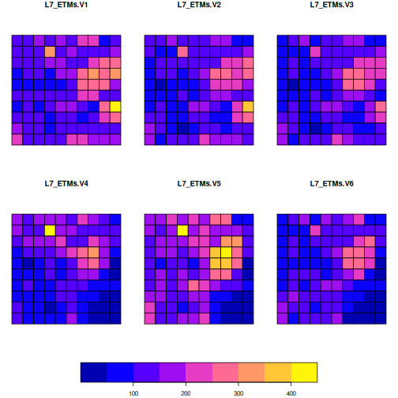

```r
plot(aw, key.pos = 1)
```

```r
sum(aa[,,1][[1]])
```

```
## [1] 15893.9
```

```r
sum(aw$L7_ETMs.V1)
```

```
## [1] 15893.9
```

Sums are preserved

### Try sampling the territory of Canada (from ne_countries()) using random sampling and a sample size of 500. Plot the points along with the country outline. Are the points randomly distributed on the plot?

```r
library(rnaturalearth)
ne = ne_countries()
which(ne$admin == "Canada")
```

```
## [1] 4
```

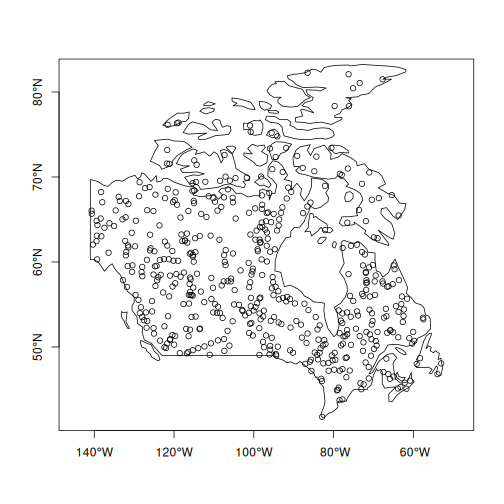

```r
# st_sample(ne[4,], 500, "Fibonacci")
p = st_sample(ne[4,], 500)
plot(p, axes = TRUE)
plot(st_geometry(ne)[4], add = TRUE)
```

### In the nc dataset, for the variables “Number of Births” and “Fraction of non-white births”, are these variables spatially extensive of intensive?

A: number: extensive; fraction: intensive.

### In the station density map shown above, what is the unit of measurement of the values shown?

Number of stations per unit area (\(m^{-2}\)). Check:

```r
library(spatstat)
library(stars)
no2 <- read.csv(system.file("external/no2.csv", package = "gstat"))
crs <- st_crs("EPSG:32632")
st_as_sf(no2, crs = "OGC:CRS84", coords =
    c("station_longitude_deg", "station_latitude_deg")) |>
    st_transform(crs) -> no2.sf
de.sf = read_sf("de_nuts1.gpkg")
de.sf |> st_transform(crs) -> de
d = density(as.ppp(st_geometry(no2.sf), as.owin(de))) |> st_as_stars()
st_dimensions(d)
```

```
##   from  to  offset delta x/y
## x    1 128  280741  5005 [x]
## y    1 128 5235822  6761 [y]
```

```r
cell = st_dimensions(d)$x$delta * st_dimensions(d)$y$delta # area size of a single
sum(d[[1]], na.rm = TRUE) * cell  # roughly equal to n=74
```

```
## [1] 71.04057
```

```r
nrow(no2)
```

```
## [1] 74
```

### For the NO2 concentration map shown above, compute the (multi-)polygon for which interpolated values are above 15.

```r
no2 <- read.csv(system.file("external/no2.csv", package = "gstat"))
crs <- st_crs("EPSG:32632")
st_as_sf(no2, crs = "OGC:CRS84", coords =
    c("station_longitude_deg", "station_latitude_deg")) |>
    st_transform(crs) -> no2.sf
de.sf |> st_transform(crs) -> de
template = st_as_stars(st_bbox(de), dx = units::set_units(10, km)) # 10 km x 10 km
de.r_utm = st_rasterize(de, template)
# de.r_utm$mask = ifelse(as.numeric(de.r_utm[[1]]) == 0, NA, 1)
library(gstat)
no2.r = gstat::idw(NO2~1, no2.sf, de.r_utm) |> st_crop(de)
```

```
## [inverse distance weighted interpolation]
```

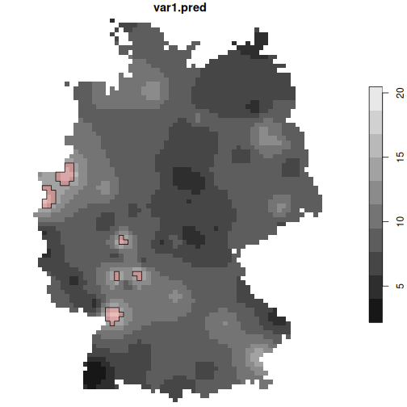

```r
no2.r$above = ifelse(no2.r$var1.pred > 15, TRUE, NA)
st_as_sf(no2.r["above"], as_points = FALSE) |> st_union() -> u
plot(no2.r, reset=FALSE, breaks = 'equal')
plot(u, add = TRUE, col = '#ff000033')
```